# B2B Project status & Plan

### Sub Process Relation Diagram

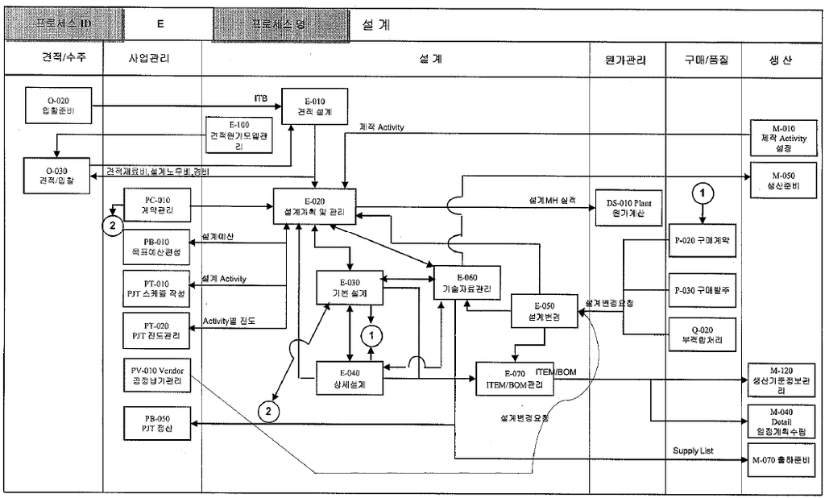

### RIVIAN

- require increase level of brightness of power
- it’ll be done by Friday
- Electrical part :
- Mid Hoop changed will be arrived by Tuesday
- SKIN : some wrong even though R’s design = Error on customer design
- change : pocket line with binding color
- just incision around between extension and main panel
- in the morning 1/10 Neil share the summary
- Let’s make sure there’s no difference between what we understand and what you explain
- Frame 5 = 2 + 3 set ( to be received from Rivian changed parts ) + 2 skin sets

### etc:

- https://blog.zarathu.com/posts/2019-01-03-rmarkdown/
- toc :
- CS 250 / year

### All B2B Milestone

[figure not shown]

### PORSCHE

- accessories : 100 pieces each of 3 items
- RTT 2.0 : major feature in new products to apply it . RF: . outlet ? . Mattress
- C/S: . warranty free of charge : Hard shell, SKIN . Bracket of ladder , Tension pole, Inner Tent, Rainfly . Procedure of claim Receiving . parts list, price list
- Accessories . accessories :

### AUDI

- follow-up
- NPD . PORSCHE Hard shell . RTT 3.0 SKIN . Mattress
- Milestone

### RIVIAN

- GEN-1 PO . Field Performance test requirements
- GEN-1 NPD . Milestone . SCM . Mounting Bracket + Locking core/key
- GEN-2 . Design change (DFM)

### GENESIS

- NPD
- Milestone

### etc

- Issues for BE : Seoul Edition 100 : Black + Highlight in RF
- EVR certification for electrical part

### Ready for B2B capability ( Y25, Y26)

- General . Doc. archive . PM Management
- Major contents by phase: Technical presentation >> Planning >> NPD >> Prototype/Pilot >> Test >> PPAP . Deliverable . FMEA . defect / defective / deficient

### R&D NP SOP launch

- SS Tent : April
- X-C 3.0 : May
- DLX : March / KCL, ISO 7322, 압축성, 회복성성
- BED Rack :

### various Products for increasing sales